# Notebook 08 – Solutions

## Getting Started

Before running this notebook, select “Session > Restart R and Clear Output” in the menu above to start a new R session. This will clear any old data sets and give us a blank slate to start with.

After starting a new session, run the following code chunk to load the libraries and data that we will be working with today.

I have set the options `include=FALSE` and `message=FALSE` to avoid cluttering the solutions with all the output from this code.

# Practice

## Load Datasets

We will work with the largest cities datasets:

```r
cities <- read_csv(file.path("data", "largest_cities.csv"))
```

We will also work with the entire U.S. cities dataset:

```r
us <- read_csv(file.path("data", "us_city_population.csv"))
```

Please refer to notebook02a for more information about these datasets and how these datasets are organized.

## Creating new numeric features

Using the `cities` dataset, create a new feature named `city_density` by dividing the city population (`city_pop`) by the city area (`city_area`). Use the `select` function to select the city name (`name`), population, area, and density.

```r
cities %>%
  mutate(city_density = city_pop / city_area) %>%
  select(name, city_pop, city_area, city_density)
```

```
## # A tibble: 81 × 4
##    name        city_pop city_area city_density
##    <chr>          <dbl>     <dbl>        <dbl>
##  1 Tokyo          13.5       2191      0.00617
##  2 Delhi          16.8       1484      0.0113
##  3 Shanghai       24.2       6341      0.00381
##  4 São Paulo      12.3       1521      0.00806
##  5 Mexico City     8.92      1485      0.00601
##  6 Cairo           9.5       3085      0.00308
##  7 Mumbai         12.5        603      0.0207
##  8 Beijing        21.7      16411      0.00132
##  9 Dhaka          14.4        338      0.0426
## 10 Osaka           2.72       225      0.0121
## # … with 71 more rows
```

The numbers here are very small. What units is the feature `city_density` currently in? **Answer**: It is given in millions of people per square kilometer.

Below, modify your code by multiplying the city density by 1000.

```r
cities %>%
  mutate(city_density = city_pop / city_area * 1000) %>%
  select(name, city_pop, city_area, city_density)
```

```
## # A tibble: 81 × 4
##    name        city_pop city_area city_density
##    <chr>          <dbl>     <dbl>        <dbl>
##  1 Tokyo          13.5       2191         6.17
##  2 Delhi          16.8       1484        11.3
##  3 Shanghai       24.2       6341         3.81
##  4 São Paulo      12.3       1521         8.06
##  5 Mexico City     8.92      1485         6.01
##  6 Cairo           9.5       3085         3.08
##  7 Mumbai         12.5        603        20.7
##  8 Beijing        21.7      16411         1.32
##  9 Dhaka          14.4        338        42.6
## 10 Osaka           2.72       225        12.1
## # … with 71 more rows
```

Now what are the units of the city density feature? **Answer**: Thousands of people per square kilometer.

Now, summarize the average city density by continent.

```r
cities %>%
  mutate(city_density = city_pop / city_area * 1000) %>%
  group_by(continent) %>%
  summarize(sm_mean(city_density))
```

```
## # A tibble: 5 × 2
##   continent     city_density_mean
##   <chr>                     <dbl>
## 1 Africa                     5.21
## 2 Asia                      10.6
## 3 Europe                     9.26
## 4 North America              3.87
## 5 South America              7.87
```

Now, below, using the mutate verb, create a plot with city density on the x-axis and metro density on the y-axis. Use a log scale for the axes and include points and text repel labels with the city names.

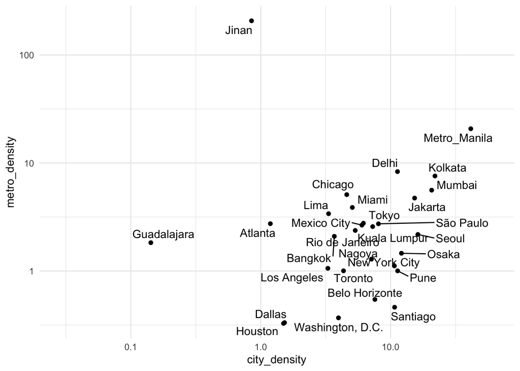

```r
cities %>%
  mutate(city_density = city_pop / city_area * 1000) %>%
  mutate(metro_density = metro_pop / metro_area * 1000) %>%
  ggplot(aes(city_density, metro_density)) +
    geom_point() +
    geom_text_repel(aes(label = name)) +
    scale_x_log10() +
    scale_y_log10()
```

What two outliers stick out in this plot? **Answer**: Guadalajara and Jinan have a much higher metro density than would be expect based on the city density.

## Creating new categorical features

Create a bar plot showing the counts of the the `koppen_code` feature in the `cities` dataset. Order the groups categories ordered from the biggest to the smallest. The labels are short so there should be no need to flip the axes in the plot.

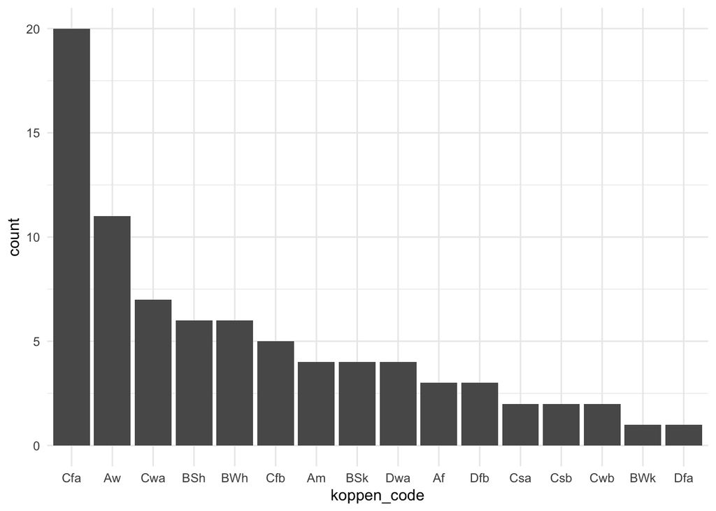

```r
cities %>%
  group_by(koppen_code) %>%
  summarize(sm_count()) %>%
  arrange(desc(count)) %>%
  mutate(koppen_code = fct_inorder(koppen_code)) %>%
  ggplot(aes(koppen_code, count)) +
    geom_col()
```

In the code below, create a new feature called `hemisphere` which is equal to “North” for cities with a latitude above zero and “South” for cities below zero. Pipe the data to a plot and color the cities by their hemisphere to verify that your code is correct.

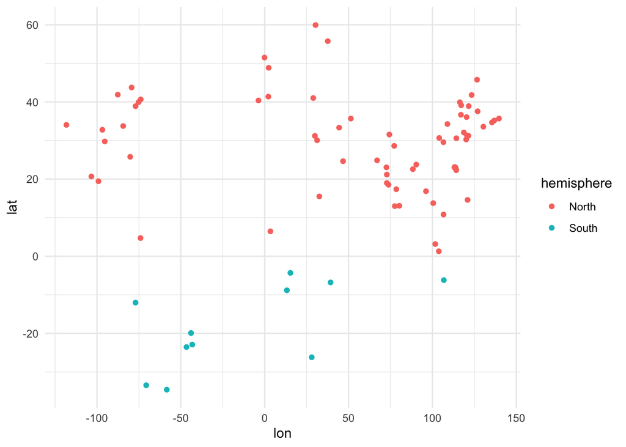

```r
cities %>%
  mutate(hemisphere = if_else(lat > 0, "North", "South")) %>%
  ggplot(aes(lon, lat)) +
    geom_point(aes(color = hemisphere))
```

Repeat this process below, but this time create a feature called “quadrant” that is equal to “NE”, “NW”, “SE”, and “SE” depending on the sign of the latitude and longitude features. The easiest way to do this is to start by defining a default value and them fill in the quadrants with four uses of the `if_else` function. Note: use the `&` operator to combine two conditions (i.e., `(lat > 0) & (lon > 0)`).

As above, pipe the data into a plot colored by quadrant to verify your work.

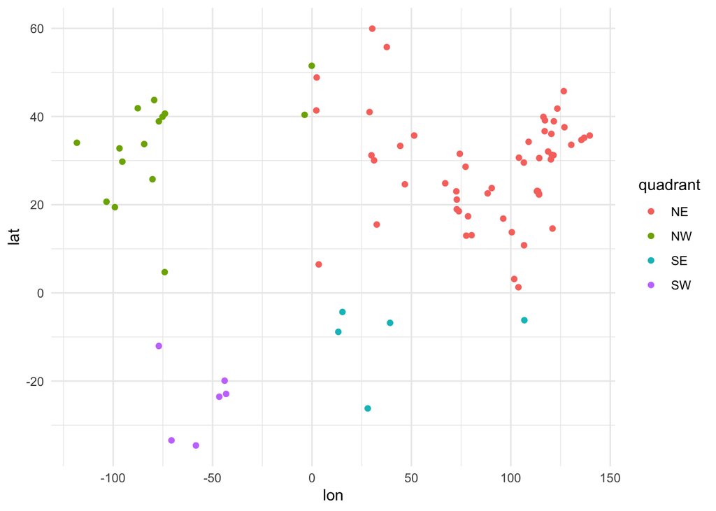

```r
cities %>%
  mutate(quadrant = "default") %>%
  mutate(quadrant = if_else((lat > 0) & (lon > 0), "NE", quadrant)) %>%
  mutate(quadrant = if_else((lat > 0) & (lon < 0), "NW", quadrant)) %>%
  mutate(quadrant = if_else((lat < 0) & (lon > 0), "SE", quadrant)) %>%
  mutate(quadrant = if_else((lat < 0) & (lon < 0), "SW", quadrant)) %>%
  ggplot(aes(lon, lat)) +
    geom_point(aes(color = quadrant))
```

## Grouped Mutate

To conclude, we will apply a few grouped versions of the mutate verb. To make sure we understand how this works, take the `us` dataset, group by city, and compute the maximum value of the population feature for each city.

```r
us %>%
  group_by(city) %>%
  mutate(sm_max(population))
```

```
## # A tibble: 6,900 × 7
## # Groups:   city [300]
##    city            state  year population    lon   lat population_max
##    <chr>           <chr> <dbl>      <dbl>  <dbl> <dbl>          <dbl>
##  1 Anchorage, AK   AK     1790          0 -149.   61.2           292.
##  2 Birmingham, AL  AL     1790          0  -86.8  33.5           341.
##  3 Huntsville, AL  AL     1790          0  -86.5  34.8           180.
##  4 Mobile, AL      AL     1790          0  -88.1  30.7           200.
##  5 Montgomery, AL  AL     1790          0  -86.3  32.3           206.
##  6 Little Rock, AR AR     1790          0  -92.4  34.7           194.
##  7 Chandler, AZ    AZ     1790          0 -112.   33.3           236.
##  8 Gilbert, AZ     AZ     1790          0 -112.   33.3           208.
##  9 Glendale, AZ    AZ     1790          0 -112.   33.5           227.
## 10 Mesa, AZ        AZ     1790          0 -112.   33.4           439.
## # … with 6,890 more rows
```

Note that this added a new column to a copy of the original dataset showing the largest population for each city at any point in time.

Building off of this approach, construct a scatter plot that shows the population of cities in 2010 on the x-axis and the percentage of the 2010 population compared to the maximum population of the city from 1790-2010. Filter to only include cities that are less than 70% of their maximum size in 2010. Use a text repel layer to label each city. (Note: This will require at least two different calls to the mutate function).

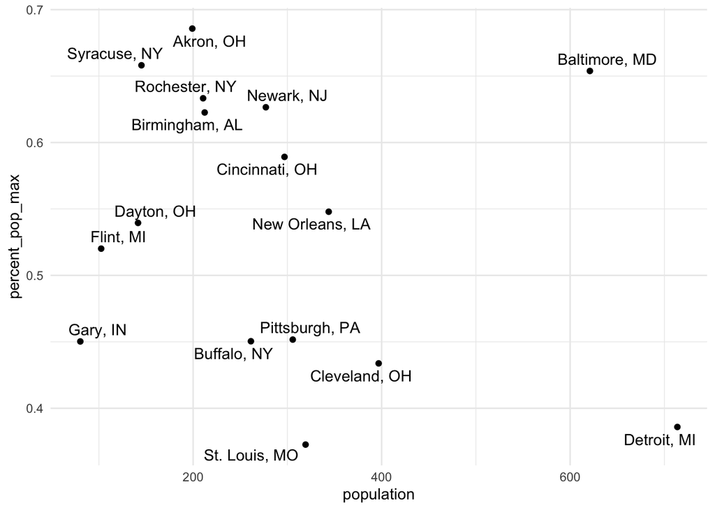

```r
us %>%
  group_by(city) %>%
  mutate(sm_max(population)) %>%
  filter(year == 2010) %>%
  mutate(percent_pop_max = population / population_max) %>%
  filter(percent_pop_max < 0.7) %>%
  ggplot(aes(population, percent_pop_max)) +
    geom_point() +
    geom_text_repel(aes(label = city))
```

## Labels and themes

In the code block below, create a visualization of the `cities` data with city population on the x-axis, city area on the y-axis, points colored by continent, and the point size given by the cities population density. Include informative labels (with units, where needed) for the axes and legends, a title, subtitle, and caption. Set the `theme_sm` theme and add logarithmic scales for the x and y axes.

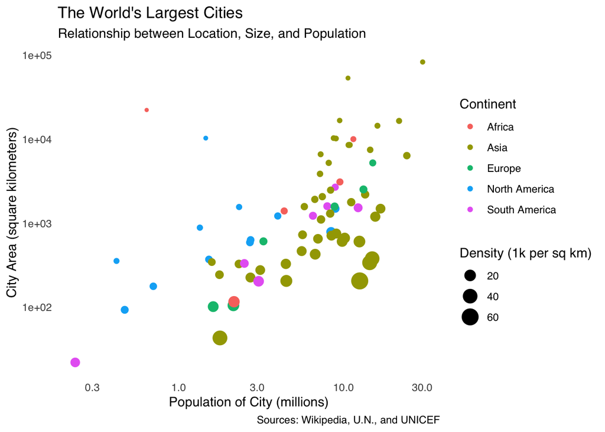

```r
theme_set(theme_sm())

cities %>%
  mutate(city_density = city_pop / city_area * 1000) %>%
  ggplot(aes(city_pop, city_area)) +
    geom_point(aes(color = continent, size = city_density)) +
    scale_x_log10() +
    scale_y_log10() +
    labs(
      x = "Population of City (millions)",
      y = "City Area (square kilometers)",
      color = "Continent",
      size = "Density (1k per sq km)",
      title = "The World's Largest Cities",
      subtitle = "Relationship between Location, Size, and Population",
      caption = "Sources: Wikipedia, U.N., and UNICEF"
    )
```